# Ford GoBike System Data

## Category of users:

The composition of users that benefit from the rental service is around 90% Subscribers that had bought an annual membership and 10% Customers that prefer to use the service on the go.

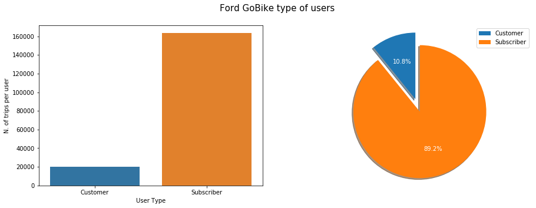

```python
plt.figure(figsize = [15, 5])

plt.subplot(1,2,1)
sb.countplot(data=bike_data, x="user_type")
plt.xlabel('User Type')
plt.ylabel('N. of trips per user')

plt.subplot(1,2,2)
customer = bike_data.query('user_type == "Customer"')['bike_id'].count()
subscriber = bike_data.query('user_type == "Subscriber"')['bike_id'].count()

customer_proportion = customer / bike_data['bike_id'].count()
subscriber_proportion = subscriber / bike_data['bike_id'].count()

prop = [customer_proportion, subscriber_proportion]
plt.pie(prop, explode=(0, 0.2), autopct='%1.1f%%', textprops={'color':'white'}, startangle=90,shadow=True)
plt.axis('equal')
plt.legend(["Customer","Subscriber"])
plt.suptitle('Ford GoBike type of users', fontsize=15);
```

## Distance covered by categories of users:

We can see that on average customers type tend to have longer distances with a peak between 1 and 2 km per trip. On the other hand Subscribers are more constant in the use of bikes, even though they cover less distance per trip (between 0.5 and 1.5 km) their frequency of usage is much higher.

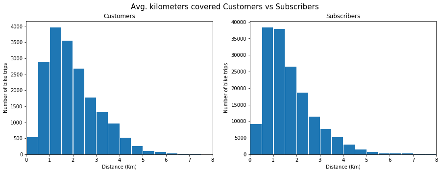

```python
plt.figure(figsize = [15, 5])

plt.subplot(1,2,1)
dist_cust = bike_data.query('user_type == "Customer" & distance_km !=0')
bins = np.arange(dist_cust.distance_km.min(), dist_cust.distance_km.max(),0.5)
plt.hist(dist_cust.distance_km, bins=bins, rwidth=0.95)
plt.xlim(0,8)
plt.xlabel("Distance (Km)")
plt.ylabel("Number of bike trips")
plt.title("Customers");

plt.subplot(1,2,2)
dist_sub = bike_data.query('user_type == "Subscriber" & distance_km !=0')
bins = np.arange(dist_sub.distance_km.min(), dist_sub.distance_km.max(),0.5)
plt.hist(dist_sub.distance_km, bins=bins, rwidth=0.95);
plt.xlim(0,8)
plt.xlabel("Distance (Km)")
plt.ylabel("Number of bike trips")
plt.title("Subscribers");

plt.suptitle("Avg. kilometers covered Customers vs Subscribers", fontsize=15);
```

## Gender of users:

The users gender composition is lead by males, with a 75%. Follow by females and others. To remark how the female proportion is less than half than males, which could lead to think about improvements on the comfort, design, or weight of the bikes.

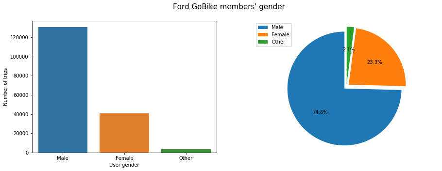

```python
plt.figure(figsize = [15, 5])

plt.subplot(1,2,1)
sb.countplot(data=bike_data, x="member_gender", order=bike_data.member_gender.value_counts().index, hue_order="member_gender")
plt.xlabel('User gender')
plt.ylabel('Number of trips')

plt.subplot(1,2,2)
male = bike_data.query('member_gender == "Male"')['member_gender'].count()
female = bike_data.query('member_gender == "Female"')['member_gender'].count()
other = bike_data.query('member_gender == "Other"')['member_gender'].count()

male_prop = male / bike_data['member_gender'].count()
female_prop = female / bike_data['member_gender'].count()
other_prop = other / bike_data['member_gender'].count()

prop = [male_prop, female_prop, other_prop]
plt.pie(prop, autopct='%1.1f%%', explode=(0.05, 0.05, 0.05), startangle=90)
plt.axis('equal')
plt.legend(["Male", "Female", "Other"])
plt.suptitle("Ford GoBike members' gender", fontsize=15);
```